# Relationship Pursuit

PSY 120L Reproducible Analysis Report

Author

Milena Chobanyan

Published

June 7, 2026

## About This Report

This report documents the workflow for the Relationship Pursuit Study with the goal of showing how the dataset was imported, cleaned, prepared, analyzed, and visualized in R. The report will include information about the study background, variables, scale construction, reliability checks, descriptive statistics, primary analyses, figures, and reproducibility information. The purpose of this report is to make the analysis process clear and reproducible so that a reader can understand how the study moved from the original dataset to the final results.

## Study Overview

The Relationship Pursuit Study examined how relationship context and commitment readiness influence romantic partner trait preferences. Participants in the study were randomly assigned to imagine either a short-term or long-term romantic relationship and then had to rate the importance of different romantic partner traits. The study focused on two types of partner traits:

1. Warmth/trustworthiness
2. Vitality/attractiveness

Warmth/trustworthiness included qualities such as honesty, loyalty, supportiveness, understanding, and trustworthiness, while vitality/attractiveness included qualities such as attractiveness, fun, energy, adventurousness, and sexiness.

Prior research suggests that people don’t value all romantic partner traits equally across every situation, but rather their goals shape which traits people prioritize. For instance, participants imagining a long-term partner may place more importance on warmth, trust, loyalty, and support, while participants imagining a short-term partner may place more importance on attractiveness, excitement, and physical appearance. The current study tested whether participants’ trait ratings differed depending on the relationship context they were assigned to and whether commitment readiness changed this pattern.

## Setup and Software Environment

**Load Packages**

```r
library(tidyverse)  # data manipulation + plotting
library(psych)      # scale construction + reliability
library(afex)       # ANOVA models + effect sizes
library(emmeans)    # estimated marginal means + confidence intervals
```

## Data Source and Analysis Data-set

The data for this report came from the Relationship Pursuit Study data-set, which includes participants’ assigned relationship condition, demographic information, commitment readiness response, and romantic partner trait ratings. The analysis data-set was created by selecting the variables needed for the current analyses and converting them into the correct format before creating the final scale scores.

### Import Data-set

```r
study_raw <- read_csv("data/relationship_pursuit_data.csv")
```

### Check Imported Data-set

```r
dim(study_raw)
```

```
[1] 71 35
```

```r
names(study_raw)
```

```
 [1] "ResponseId"           "DistributionChannel"  "consent"
 [4] "Long_Term_Traits_1"   "Long_Term_Traits_2"   "Long_Term_Traits_3"
 [7] "Long_Term_Traits_4"   "Long_Term_Traits_5"   "Long_Term_Traits_6"
[10] "Long_Term_Traits_7"   "Long_Term_Traits_8"   "Long_Term_Traits_9"
[13] "Long_Term_Traits_10"  "Short_Term_Traits_1"  "Short_Term_Traits_2"
[16] "Short_Term_Traits_3"  "Short_Term_Traits_4"  "Short_Term_Traits_5"
[19] "Short_Term_Traits_6"  "Short_Term_Traits_7"  "Short_Term_Traits_8"
[22] "Short_Term_Traits_9"  "Short_Term_Traits_10" "check"
[25] "Commit_1"             "Commit_2"             "Commit_3"
[28] "Commit_4"             "Commit_5"             "Commit_6"
[31] "Commit_7"             "Commit_8"             "age"
[34] "sex"                  "condition"
```

```r
head(study_raw)
```

```
# A tibble: 6 × 35
  ResponseId   DistributionChannel consent Long_Term_Traits_1 Long_Term_Traits_2
  <chr>        <chr>                 <dbl>              <dbl>              <dbl>
1 R_5DqGp4GTV… email                     1                 NA                 NA
2 R_5FjKOfBut… email                     1                  7                  7
3 R_12EXz22Ua… email                     1                 NA                 NA
4 R_10wYoD2Qc… anonymous                 1                 NA                 NA
5 R_3EiuvYYtL… anonymous                 1                  7                  7
6 R_1MSSHU33V… anonymous                 1                  7                  7
# ℹ 30 more variables: Long_Term_Traits_3 <dbl>, Long_Term_Traits_4 <dbl>,
#   Long_Term_Traits_5 <dbl>, Long_Term_Traits_6 <dbl>,
#   Long_Term_Traits_7 <dbl>, Long_Term_Traits_8 <dbl>,
#   Long_Term_Traits_9 <dbl>, Long_Term_Traits_10 <dbl>,
#   Short_Term_Traits_1 <dbl>, Short_Term_Traits_2 <dbl>,
#   Short_Term_Traits_3 <dbl>, Short_Term_Traits_4 <dbl>,
#   Short_Term_Traits_5 <dbl>, Short_Term_Traits_6 <dbl>, …
```

This section of the data-set contains 71 entries and 35 total columns. The rows show participants’ response information, consent/check variables, long-term vs. short-term trait-rating items, commitment-readiness items, condition, and participant demographics, such as age and sex. The output did show some “NA” values in the columns, which is expected since participants were assigned to either the short-term or long-term relationship condition and only answered the trait items for their assigned condition. This output confirmed that the data-set imported correctly and that the expected study variables are present.

### Create Analysis Data-set

```r
study_vars <- c(
     "condition", "check", "sex","age",

     "Commit_1","Commit_2","Commit_3","Commit_4",
     "Commit_5","Commit_6","Commit_7","Commit_8",

      "Long_Term_Traits_1","Long_Term_Traits_2","Long_Term_Traits_3",
      "Long_Term_Traits_4","Long_Term_Traits_5","Long_Term_Traits_6",
      "Long_Term_Traits_7","Long_Term_Traits_8","Long_Term_Traits_9",
      "Long_Term_Traits_10",

      "Short_Term_Traits_1","Short_Term_Traits_2","Short_Term_Traits_3",
      "Short_Term_Traits_4","Short_Term_Traits_5","Short_Term_Traits_6",
       "Short_Term_Traits_7","Short_Term_Traits_8","Short_Term_Traits_9",
      "Short_Term_Traits_10" # Short-term items

      )

study_data <- study_raw %>%
  select(all_of(study_vars)) %>%
  mutate(
    across(everything(), as.numeric)
  )
```

### Check Analysis Data-set

```r
length(study_vars)
```

```
[1] 32
```

```r
dim(study_data)
```

```
[1] 71 32
```

```r
names(study_data)
```

```
 [1] "condition"            "check"                "sex"
 [4] "age"                  "Commit_1"             "Commit_2"
 [7] "Commit_3"             "Commit_4"             "Commit_5"
[10] "Commit_6"             "Commit_7"             "Commit_8"
[13] "Long_Term_Traits_1"   "Long_Term_Traits_2"   "Long_Term_Traits_3"
[16] "Long_Term_Traits_4"   "Long_Term_Traits_5"   "Long_Term_Traits_6"
[19] "Long_Term_Traits_7"   "Long_Term_Traits_8"   "Long_Term_Traits_9"
[22] "Long_Term_Traits_10"  "Short_Term_Traits_1"  "Short_Term_Traits_2"
[25] "Short_Term_Traits_3"  "Short_Term_Traits_4"  "Short_Term_Traits_5"
[28] "Short_Term_Traits_6"  "Short_Term_Traits_7"  "Short_Term_Traits_8"
[31] "Short_Term_Traits_9"  "Short_Term_Traits_10"
```

The data-set included 32 selected variables from the original raw data-set, which was confirmed by the length(study_vars) function and the dim(study_data) function showed that the cleaned analysis data-set contained 71 participants and 32 variables. The variables confirmed that the data-set included the condition, check, sex, age, eight commitment readiness items, ten long-term trait items, and ten short-term trait items. This section of output confirmed that the analysis data-set was correct and contained the necessary variables.

## Variable Preparation

This section prepares the variables needed for the analyses. The code creates a participant ID variable, recodes the experimental condition into meaningful labels, recodes sex into readable categories, reverse-codes the necessary items, combines the short-term and long-term trait responses, and creates average scale scores. These steps help with interpretation and ensure that higher scores represent higher levels of the intended construct.

### Prepare Participant ID and Experimental Condition

```r
study_data <- study_data %>%
  mutate(
    id = row_number(),
    condition = factor(
      condition,
      levels = c(0, 1),
      labels = c("Short-Term", "Long-Term")
    ),
    sex = case_when(
      sex == 1 ~ "Male",
      sex == 2 ~ "Female",
      TRUE ~ NA_character_
    ),
    sex = factor(
      sex,
      levels = c("Female", "Male")
    )
  )
```

This code prepared the participant ID, condition, and sex variables for analysis. A new ID variable was created so that each participant had a unique row number, and the condition variable was recoded from numeric values into meaningful labels:

- 0 = “Short-Term”
- 1 = “Long-Term”
- 1 = “Male”
- 2 = “Female”

### Check Experimental Condition Coding

```r
study_data %>%
  count(condition) %>%
  knitr::kable(
    col.names = c("Condition", "n")
  )
```

| Condition | n |
| --- | --- |
| Short-Term | 34 |
| Long-Term | 35 |
| NA | 2 |

```r
study_data %>%
  count(sex) %>%
  knitr::kable(
    col.names = c("Sex", "n")
  )
```

| Sex | n |
| --- | --- |
| Female | 57 |
| Male | 8 |
| NA | 6 |

The output showed that 34 participants were in the Short-Term condition and 35 participants were in the Long-Term condition, with 2 participants missing condition information. These results suggest that participants were mostly evenly distributed across the conditions (short-term vs. long-term). The sex table showed that 57 participants were coded as Female, 8 as Male, and 6 had missing sex information.

### Check Prepared Analysis Data-set

```r
dim(study_data)
```

```
[1] 71 33
```

```r
names(study_data)
```

```
 [1] "condition"            "check"                "sex"
 [4] "age"                  "Commit_1"             "Commit_2"
 [7] "Commit_3"             "Commit_4"             "Commit_5"
[10] "Commit_6"             "Commit_7"             "Commit_8"
[13] "Long_Term_Traits_1"   "Long_Term_Traits_2"   "Long_Term_Traits_3"
[16] "Long_Term_Traits_4"   "Long_Term_Traits_5"   "Long_Term_Traits_6"
[19] "Long_Term_Traits_7"   "Long_Term_Traits_8"   "Long_Term_Traits_9"
[22] "Long_Term_Traits_10"  "Short_Term_Traits_1"  "Short_Term_Traits_2"
[25] "Short_Term_Traits_3"  "Short_Term_Traits_4"  "Short_Term_Traits_5"
[28] "Short_Term_Traits_6"  "Short_Term_Traits_7"  "Short_Term_Traits_8"
[31] "Short_Term_Traits_9"  "Short_Term_Traits_10" "id"
```

The prepared analysis data-set displayed 71 participants and 33 variables. The reason for the extra variable is due to the additional variable (ID), which was created to give each participant a unique ID number.

### Reverse-Code Scale Items

Some of the items were reverse-coded because those items were worded in the opposite direction from the other items. Since the survey used a 1 to 7 scale, reverse-coding was done by subtracting each response from 8. For instance, a score of 1 became 7, a score of 2 became 6, and so on. This made sure that all items were scored in the same direction before they were averaged together.

```r
study_data <- study_data %>%
  mutate(

    Commit_2r  = 8 - Commit_2,
    Commit_4r  = 8 - Commit_4,
    Commit_6r = 8 - Commit_6,
    Commit_8r = 8 - Commit_8,

    Long_Term_Traits_3r  = 8 - Long_Term_Traits_3,
    Long_Term_Traits_4r  = 8 - Long_Term_Traits_4,
    Long_Term_Traits_6r = 8 - Long_Term_Traits_6,
    Long_Term_Traits_7r = 8 - Long_Term_Traits_7,
    Long_Term_Traits_10r = 8 - Long_Term_Traits_10,

    Short_Term_Traits_3r  = 8 - Short_Term_Traits_3,
    Short_Term_Traits_4r  = 8 - Short_Term_Traits_4,
    Short_Term_Traits_6r = 8 - Short_Term_Traits_6,
    Short_Term_Traits_7r = 8 - Short_Term_Traits_7,
    Short_Term_Traits_10r = 8 - Short_Term_Traits_10


  )
```

### Check Reverse Coding

```r
study_data %>%
  select(
    Commit_2, Commit_2r,
    Long_Term_Traits_3, Long_Term_Traits_3r,
    Short_Term_Traits_3, Short_Term_Traits_3r
  ) %>%
  head(10) %>%
  knitr::kable()
```

| Commit_2 | Commit_2r | Long_Term_Traits_3 | Long_Term_Traits_3r | Short_Term_Traits_3 | Short_Term_Traits_3r |
| --- | --- | --- | --- | --- | --- |
| 3 | 5 | NA | NA | 5 | 3 |
| 5 | 3 | 7 | 1 | NA | NA |
| 1 | 7 | NA | NA | 5 | 3 |
| 5 | 3 | NA | NA | 5 | 3 |
| 1 | 7 | 4 | 4 | NA | NA |
| 1 | 7 | 5 | 3 | NA | NA |
| 1 | 7 | NA | NA | 7 | 1 |
| 1 | 7 | 4 | 4 | NA | NA |
| 3 | 5 | NA | NA | 7 | 1 |
| 1 | 7 | 5 | 3 | NA | NA |

### Combine Trait Responses

```r
study_data <- study_data %>%
  mutate(
    trait_1  = coalesce(Long_Term_Traits_1,  Short_Term_Traits_1),
    trait_2  = coalesce(Long_Term_Traits_2,  Short_Term_Traits_2),
    trait_3  = coalesce(Long_Term_Traits_3r, Short_Term_Traits_3r),
    trait_4  = coalesce(Long_Term_Traits_4r, Short_Term_Traits_4r),
    trait_5  = coalesce(Long_Term_Traits_5,  Short_Term_Traits_5),
    trait_6  = coalesce(Long_Term_Traits_6r, Short_Term_Traits_6r),
    trait_7  = coalesce(Long_Term_Traits_7r, Short_Term_Traits_7r),
    trait_8  = coalesce(Long_Term_Traits_8,  Short_Term_Traits_8),
    trait_9  = coalesce(Long_Term_Traits_9,  Short_Term_Traits_9),
    trait_10 = coalesce(Long_Term_Traits_10r, Short_Term_Traits_10r)
  )
```

### Check Trait Variables

```r
study_data %>%
  select(
    condition,
    Long_Term_Traits_1,
    Short_Term_Traits_1,
    trait_1,
    Long_Term_Traits_3r,
    Short_Term_Traits_3r,
    trait_3
  ) %>%
  head(10) %>%
  knitr::kable()
```

| condition | Long_Term_Traits_1 | Short_Term_Traits_1 | trait_1 | Long_Term_Traits_3r | Short_Term_Traits_3r | trait_3 |
| --- | --- | --- | --- | --- | --- | --- |
| Short-Term | NA | 5 | 5 | NA | 3 | 3 |
| Long-Term | 7 | NA | 7 | 1 | NA | 1 |
| Short-Term | NA | 1 | 1 | NA | 3 | 3 |
| Short-Term | NA | 6 | 6 | NA | 3 | 3 |
| Long-Term | 7 | NA | 7 | 4 | NA | 4 |
| Long-Term | 7 | NA | 7 | 3 | NA | 3 |
| Short-Term | NA | 5 | 5 | NA | 1 | 1 |
| Long-Term | 7 | NA | 7 | 4 | NA | 4 |
| Short-Term | NA | 7 | 7 | NA | 1 | 1 |
| Long-Term | 5 | NA | 5 | 3 | NA | 3 |

### Create Scale Scores

This section created the final scale scores that will be used in the analysis. The commitment readiness score was created by averaging the eight commitment items after necessary reverse-coding, and the trait scores were created by averaging the combined trait items. By averaging the scores, it made it easier to use each participant’s overall commitment readiness and trait rating in the descriptive statistics and ANOVA models.

```r
commit_items <- c("Commit_1", "Commit_2r", "Commit_3", "Commit_4r", "Commit_5", "Commit_6r", "Commit_7", "Commit_8r")

trait_items <- c("trait_1", "trait_2", "trait_3", "trait_4", "trait_5", "trait_6", "trait_7", "trait_8", "trait_9", "trait_10")

study_data <- study_data %>%
  mutate(
    commit_scale = rowMeans(across(all_of(commit_items)), na.rm = TRUE),
    trait_scale = rowMeans(across(all_of(trait_items)), na.rm = TRUE)
  )
```

### Check Scale Scores

```r
study_data %>%
  select(
    commit_scale,
    trait_scale
  ) %>%
  summary()
```

```
  commit_scale    trait_scale
 Min.   :1.000   Min.   :1.700
 1st Qu.:3.871   1st Qu.:3.400
 Median :5.188   Median :4.211
 Mean   :5.022   Mean   :4.086
 3rd Qu.:6.281   3rd Qu.:4.900
 Max.   :7.000   Max.   :5.600
 NA's   :3       NA's   :3
```

```r
study_data %>%
  summarise(
    commit_scale_missing = mean(is.na(commit_scale)),
    trait_scale_missing = mean(is.na(trait_scale))
  ) %>%
  knitr::kable()
```

| commit_scale_missing | trait_scale_missing |
| --- | --- |
| 0.0422535 | 0.0422535 |

The scale score summary indicated that commitment readiness scores ranged from 1.00 to 7.00, with a mean of 5.02. Trait scores ranged from 1.70 to 5.60, with a mean of 4.09. Furthermore, it showed that both scale variables had 3 missing values, which means that most participants had usable scale scores. The missingness table showed that about 4.2% of values were missing for both the commitment readiness scale and the trait scale. The output confirmed that the scale scores were correct and ready to use in the analyses.

### Create Commitment Median Split

```r
commit_median <- median(study_data$commit_scale, na.rm = TRUE)

study_data <- study_data %>%
  mutate(
    commit_msplit = if_else(
      commit_scale <= commit_median,
      "Low Commitment",
      "High Commitment"
    ),
    commit_msplit = factor(
      commit_msplit,
      levels = c("Low Commitment", "High Commitment")
    )
  )

commit_median
```

```
[1] 5.1875
```

```r
study_data %>%
  count(commit_msplit) %>%
  knitr::kable(
    col.names = c("Commitment Group", "n")
  )
```

| Commitment Group | n |
| --- | --- |
| Low Commitment | 34 |
| High Commitment | 34 |
| NA | 3 |

### Check Scale Reliability

The scale reliability was used to evaluate whether the items within each scale measured the same general construct. Cronbach’s alpha and McDonald’s omega were calculated for both the commitment readiness scale and the trait rating scale. Higher reliability values indicate that the items are more internally consistent and can be interpreted as a stronger scale.

```r
commit_item_df <- study_data %>%
  select(all_of(commit_items))

trait_item_df <- study_data %>%
  select(all_of(trait_items))

commit_alpha <- psych::alpha(commit_item_df)
commit_omega <- psych::omega(commit_item_df, plot = FALSE)

trait_alpha <- psych::alpha(trait_item_df)
```

```
Some items ( trait_7 ) were negatively correlated with the first principal component and
probably should be reversed.
To do this, run the function again with the 'check.keys=TRUE' option
```

```r
trait_omega <- psych::omega(trait_item_df, plot = FALSE)

reliability_table <- tibble(
  scale = c("Commitment", "Traits"),
  alpha = c(
    commit_alpha$total$raw_alpha,
    trait_alpha$total$raw_alpha
  ),
  omega = c(
    commit_omega$omega.tot,
    trait_omega$omega.tot
  )
)

reliability_table %>%
  mutate(
    alpha = round(alpha, 2),
    omega = round(omega, 2)
  ) %>%
  knitr::kable(
    col.names = c("Scale", "Cronbach's alpha", "McDonald's omega")
  )
```

| Scale | Cronbach’s alpha | McDonald’s omega |
| --- | --- | --- |
| Commitment | 0.94 | 0.97 |
| Traits | 0.81 | 0.90 |

The reliability table indicated that both scales had strong internal consistency. The Commitment scale had a Cronbach’s alpha of .94 and McDonald’s omega of .97, which suggests that the commitment readiness items were highly consistent with each other. The Traits scale had a Cronbach’s alpha of .81 and McDonald’s omega of .90, which also suggests good reliability. Additionally, R also produced a warning that “trait_7” may be negatively correlated with the first principal component. However, because the overall reliability values for the Traits scale were still good, the full trait scale was retained for the current analyses.

## Descriptive Statistics

The descriptive statistics look at the main variables before the primary analyses. Descriptive statistics are reported for the continuous scale scores, including commitment readiness and trait ratings. The sample composition is also summarized using age and sex so that the reader can understand who participated in the study.

### Scale Score Descriptives

```r
# Descriptive statistics for continuous scale variables
psych::describe(
  study_data %>% select(commit_scale, trait_scale)
) %>%
  knitr::kable(digits = 2)
```

|  | vars | n | mean | sd | median | trimmed | mad | min | max | range | skew | kurtosis | se |
| --- | --- | --- | --- | --- | --- | --- | --- | --- | --- | --- | --- | --- | --- |
| commit_scale | 1 | 68 | 5.02 | 1.56 | 5.19 | 5.14 | 1.76 | 1.0 | 7.0 | 6.0 | -0.54 | -0.47 | 0.19 |
| trait_scale | 2 | 68 | 4.09 | 0.98 | 4.21 | 4.14 | 1.02 | 1.7 | 5.6 | 3.9 | -0.56 | -0.75 | 0.12 |

The table showed that 68 participants had usable scores for both the commitment readiness scale and the trait scale. Commitment readiness scores had a mean of 5.02 with a standard deviation of 1.56, showing that participants generally reported moderate to high commitment readiness. Trait scores had a mean of 4.09 with a standard deviation of 0.98, suggesting that average trait ratings were around the middle of the 1 to 7 response scale.

### Sample Composition by Age and Gender

```r
study_data %>%
  summarise(
    mean_age = round(mean(age, na.rm = TRUE), 2),
    sd_age = round(sd(age, na.rm = TRUE), 2),
    min_age = min(age, na.rm = TRUE),
    max_age = max(age, na.rm = TRUE)
  ) %>%
  knitr::kable(
    col.names = c("Mean Age", "SD Age", "Minimum Age", "Maximum Age")
  )
```

| Mean Age | SD Age | Minimum Age | Maximum Age |
| --- | --- | --- | --- |
| 21.26 | 1.14 | 19 | 27 |

```r
study_data %>%
  count(sex) %>%
  mutate(percent = round(100 * n / sum(n), 1)) %>%
  knitr::kable(
    col.names = c("Sex", "n", "Percent")
  )
```

| Sex | n | Percent |
| --- | --- | --- |
| Female | 57 | 80.3 |
| Male | 8 | 11.3 |
| NA | 6 | 8.5 |

The sample composition tables showed that participants had a mean age of 21.26 years, with a standard deviation of 1.14. The youngest participant was 19 years old and the oldest participant was 27 years old. The sex distribution showed that 57 participants were female, 8 participants were male, and 6 participants had missing sex information. This means that most of the sample identified as female, with females making up 80.3% of the sample, males making up 11.3%, and missing responses making up 8.5%.

## Primary Analyses

This section tested whether romantic partner trait ratings differed based on relationship condition and individual differences. Two 2 × 2 between-subjects ANOVAs were conducted. The first ANOVA tested whether trait ratings differed by relationship condition, sex, and the interaction between condition and sex. The second ANOVA tested whether trait ratings differed by relationship condition, commitment readiness group, and the interaction between condition and commitment readiness. Estimated marginal means were also calculated to help interpret the average trait ratings across groups.

### Trait Model Condition × Sex

```r
a1_trait_sex <- afex::aov_ez(
  id = "id",
  dv = "trait_scale",
  between = c("condition", "sex"),
  data = study_data
)

a1_trait_sex
```

```
Anova Table (Type 3 tests)

Response: trait_scale
         Effect    df  MSE         F  ges p.value
1     condition 1, 61 0.49 34.71 *** .363   <.001
2           sex 1, 61 0.49      0.58 .009    .451
3 condition:sex 1, 61 0.49      1.27 .020    .264
---
Signif. codes:  0 '***' 0.001 '**' 0.01 '*' 0.05 '+' 0.1 ' ' 1
```

### Estimated Means for Trait Condition × Sex

```r
emmeans(a1_trait_sex, ~ condition)
```

```
 condition  emmean    SE df lower.CL upper.CL
 Short-Term   3.22 0.187 61     2.85     3.60
 Long-Term    4.78 0.186 61     4.40     5.15

Results are averaged over the levels of: sex
Confidence level used: 0.95
```

```r
emmeans(a1_trait_sex, ~ sex)
```

```
 sex    emmean     SE df lower.CL upper.CL
 Female    4.1 0.0925 61     3.91     4.28
 Male      3.9 0.2470 61     3.41     4.39

Results are averaged over the levels of: condition
Confidence level used: 0.95
```

```r
emmeans(a1_trait_sex, ~ condition * sex)
```

```
 condition  sex    emmean    SE df lower.CL upper.CL
 Short-Term Female   3.47 0.132 61     3.21     3.74
 Long-Term  Female   4.73 0.130 61     4.47     4.99
 Short-Term Male     2.98 0.349 61     2.28     3.67
 Long-Term  Male     4.83 0.349 61     4.13     5.52

Confidence level used: 0.95
```

### Trait Model: Condition × Commitment Model

```r
a2_trait_commit <- afex::aov_ez(
  id = "id",
  dv = "trait_scale",
  between = c("condition", "commit_msplit"),
  data = study_data
)

a2_trait_commit
```

```
Anova Table (Type 3 tests)

Response: trait_scale
                   Effect    df  MSE         F   ges p.value
1               condition 1, 64 0.49 67.22 ***  .512   <.001
2           commit_msplit 1, 64 0.49      1.64  .025    .205
3 condition:commit_msplit 1, 64 0.49      0.00 <.001    .965
---
Signif. codes:  0 '***' 0.001 '**' 0.01 '*' 0.05 '+' 0.1 ' ' 1
```

### Estimated Means for Trait: Condition × Commitment Group

```r
emmeans(a2_trait_commit, ~ condition)
```

```
 condition  emmean    SE df lower.CL upper.CL
 Short-Term   3.37 0.122 64     3.12     3.61
 Long-Term    4.76 0.119 64     4.53     5.00

Results are averaged over the levels of: commit_msplit
Confidence level used: 0.95
```

```r
emmeans(a2_trait_commit, ~ commit_msplit)
```

```
 commit_msplit   emmean    SE df lower.CL upper.CL
 Low Commitment    4.17 0.120 64     3.93     4.41
 High Commitment   3.96 0.121 64     3.71     4.20

Results are averaged over the levels of: condition
Confidence level used: 0.95
```

```r
emmeans(a2_trait_commit, ~ condition * commit_msplit)
```

```
 condition  commit_msplit   emmean    SE df lower.CL upper.CL
 Short-Term Low Commitment    3.48 0.165 64     3.15     3.81
 Long-Term  Low Commitment    4.87 0.175 64     4.52     5.22
 Short-Term High Commitment   3.25 0.181 64     2.89     3.61
 Long-Term  High Commitment   4.66 0.160 64     4.34     4.98

Confidence level used: 0.95
```

## Figures

The figures helped display the estimated mean trait scores across relationship conditions and the grouping variables. Bar plots with 95% confidence intervals were created to make it easier to compare average trait ratings across conditions, sex, and commitment readiness groups.

### Trait: Condition x Sex Interaction Plot

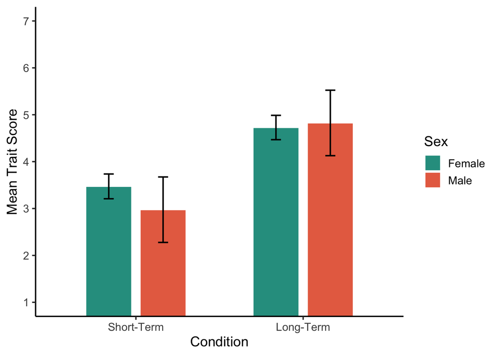

```r
p_trait_condition_sex_bar <- ggplot(
  as.data.frame(emmeans(a1_trait_sex, ~ condition * sex)),
  aes(
    x = condition,
    y = emmean,
    fill = sex
  )
) +
  geom_col(
    position = position_dodge(width = 0.65),
    width = 0.55,
    color = "white"
  ) +
  geom_errorbar(
    aes(
      ymin = lower.CL,
      ymax = upper.CL
    ),
    position = position_dodge(width = 0.65),
    width = 0.12,
    linewidth = 0.7
  ) +
  labs(
    x = "Condition",
    y = "Mean Trait Score",
    fill = "Sex"
  ) +
  scale_fill_manual(
    values = c(
      "Male" = "#E76F51",
      "Female" = "#2A9D8F"
    )
  ) +
  scale_y_continuous(
    breaks = seq(1, 7, 1)
  ) +
  coord_cartesian(
    ylim = c(1, 7)
  ) +
  theme_classic(
    base_size = 14
  )

p_trait_condition_sex_bar
```

The figure shows mean trait scores across the Short-Term and Long-Term relationship conditions, which have been separated by sex. Participants in the Long-Term condition had higher mean trait scores than participants in the Short-Term condition. This pattern was true for both female and male participants, which suggests that relationship context was related to trait ratings across sex groups. The figure does not show a strong visual interaction between condition and sex because the general pattern was similar for both groups.

### Trait: Condition × Commitment Interaction Plot

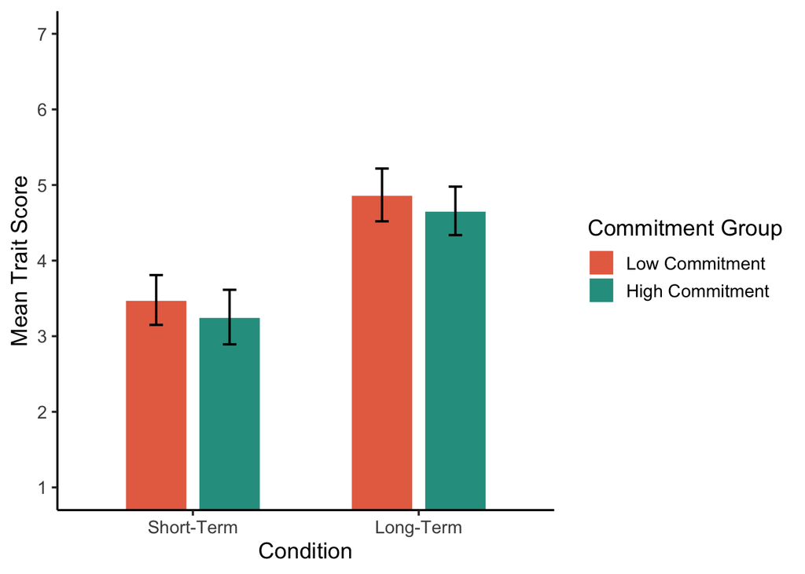

```r
p_trait_condition_commit_bar <- ggplot(
  as.data.frame(emmeans(a2_trait_commit, ~ condition * commit_msplit)),
  aes(
    x = condition,
    y = emmean,
    fill = commit_msplit
  )
) +
  geom_col(
    position = position_dodge(width = 0.65),
    width = 0.55,
    color = "white"
  ) +
  geom_errorbar(
    aes(
      ymin = lower.CL,
      ymax = upper.CL
    ),
    position = position_dodge(width = 0.65),
    width = 0.12,
    linewidth = 0.7
  ) +
  labs(
    x = "Condition",
    y = "Mean Trait Score",
    fill = "Commitment Group"
  ) +
  scale_fill_manual(
    values = c(
      "Low Commitment" = "#E76F51", # YOU CAN CHANGE THESE HEX VALUES TO MATCH YOUR POSTER!
      "High Commitment" = "#2A9D8F"
    )
  ) +
  scale_y_continuous(
    breaks = seq(1, 7, 1)
  ) +
  coord_cartesian(
    ylim = c(1, 7)
  ) +
  theme_classic(
    base_size = 14
  )

p_trait_condition_commit_bar
```

This figure shows mean trait scores across the Short-Term and Long-Term relationship conditions, which were separated by commitment readiness groups. Participants in the Long–Term condition had higher mean trait scores than participants in the Short-Term condition for both low and high commitment readiness groups. The pattern looked similar across commitment groups, suggesting that commitment readiness did not strongly change the relationship between condition and trait ratings.

### Export Figures

```r
if (!dir.exists("figures")) {
  dir.create("figures")
}

ggsave(
  filename = "figures/trait_condition_sex_interaction_plot.svg",
  plot = p_trait_condition_sex_bar,
  width = 7,
  height = 5
)

ggsave(
  filename = "figures/trait_condition_commitment_interaction_plot.svg",
  plot = p_trait_condition_commit_bar,
  width = 7,
  height = 5
)
```

Exporting the figures as separate files makes the project more organized and reproducible since the same plots can be used later in the report, presentation, or anything else. This also confirms that the figures were generated from the analysis code rather than added manually.

## Results Summary

The results showed that relationship context was essential for romantic partner trait ratings. Participants gave higher trait ratings in the Long-Term condition than in the Short-Term condition, meaning that people placed more importance on these partner traits when thinking about a longer-term relationship. This pattern appeared across both sex groups and both commitment readiness groups. However, Commitment readiness did not seem to strongly change the pattern of the results since both low and high commitment groups showed similar differences between the Short-Term and Long-Term conditions.